# nhst_recap

## [Check-In: a quick study from last class we didn’t do….](https://docs.google.com/forms/d/e/1FAIpQLSfJC8RLLtQf0Px0yz1nJjx-8CGXFrMcuUg_b3od54kHHPCEHQ/viewform?usp=sf_link)

- No talking, no looking up answers!
- Will use data in lecture :)

[figure not shown]

## Okay, some NHST Examples

- model 1
- model 2

```
Call:
lm(formula = salary ~ yrs.service, data = Salaries)

Residuals:
   Min     1Q Median     3Q    Max
-81933 -20511  -3776  16417 101947

Coefficients:
            Estimate Std. Error t value Pr(>|t|)
(Intercept)  99974.7     2416.6   41.37  < 2e-16 ***
yrs.service    779.6      110.4    7.06 7.53e-12 ***
---
Signif. codes:  0 '***' 0.001 '**' 0.01 '*' 0.05 '.' 0.1 ' ' 1

Residual standard error: 28580 on 395 degrees of freedom
Multiple R-squared:  0.1121,    Adjusted R-squared:  0.1098
F-statistic: 49.85 on 1 and 395 DF,  p-value: 7.529e-12
```

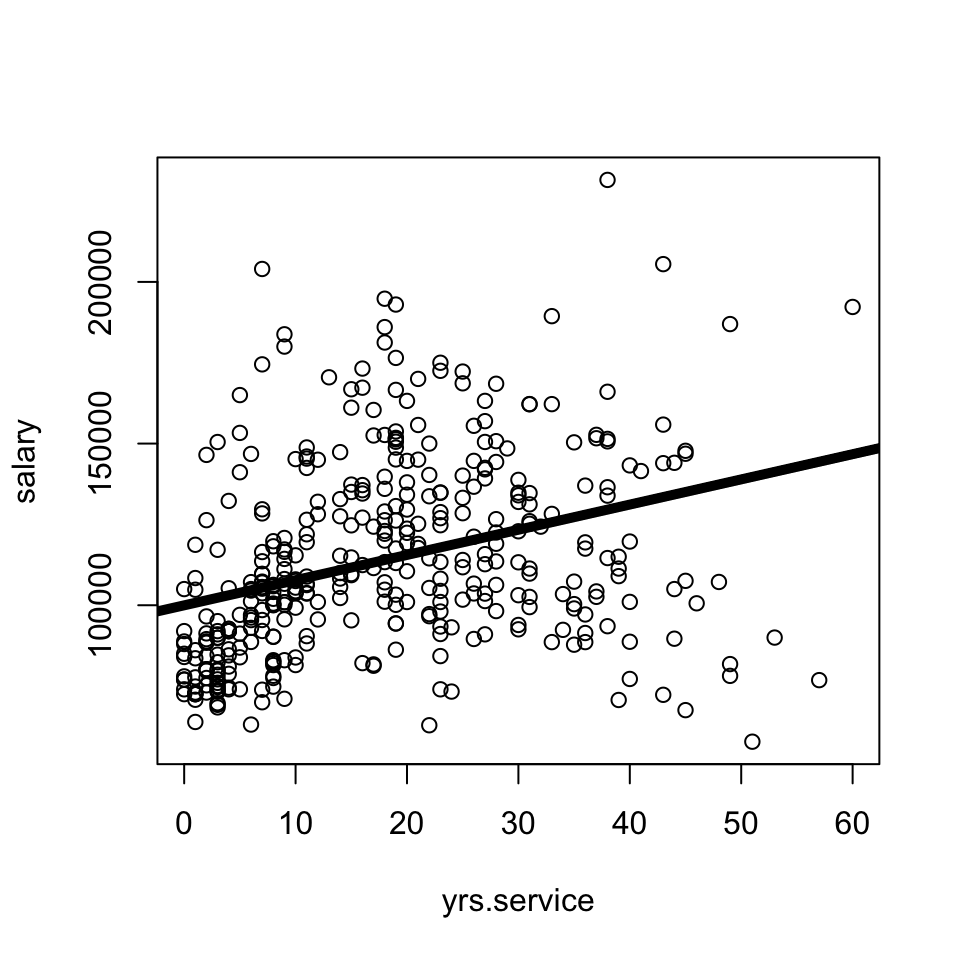

```
Call:
lm(formula = salary ~ sex, data = Salaries)

Residuals:
   Min     1Q Median     3Q    Max
-57290 -23502  -6828  19710 116455

Coefficients:
            Estimate Std. Error t value Pr(>|t|)
(Intercept)   101002       4809  21.001  < 2e-16 ***
sexMale        14088       5065   2.782  0.00567 **
---
Signif. codes:  0 '***' 0.001 '**' 0.01 '*' 0.05 '.' 0.1 ' ' 1

Residual standard error: 30030 on 395 degrees of freedom
Multiple R-squared:  0.01921,   Adjusted R-squared:  0.01673
F-statistic: 7.738 on 1 and 395 DF,  p-value: 0.005667
```

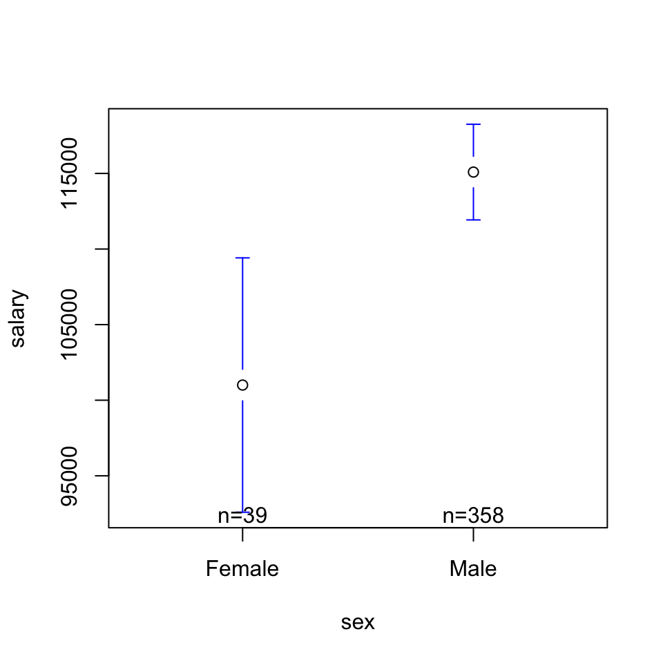

## Ch 8 Review.

- Slope
- Standard Error
- Significance is Not…
- Significance is Not
- Significance Is…
- …Confusing.
- Other Questions?
- Direction & Strength of a Relationship
- Hard to evaluate strength across models if the units differ too.

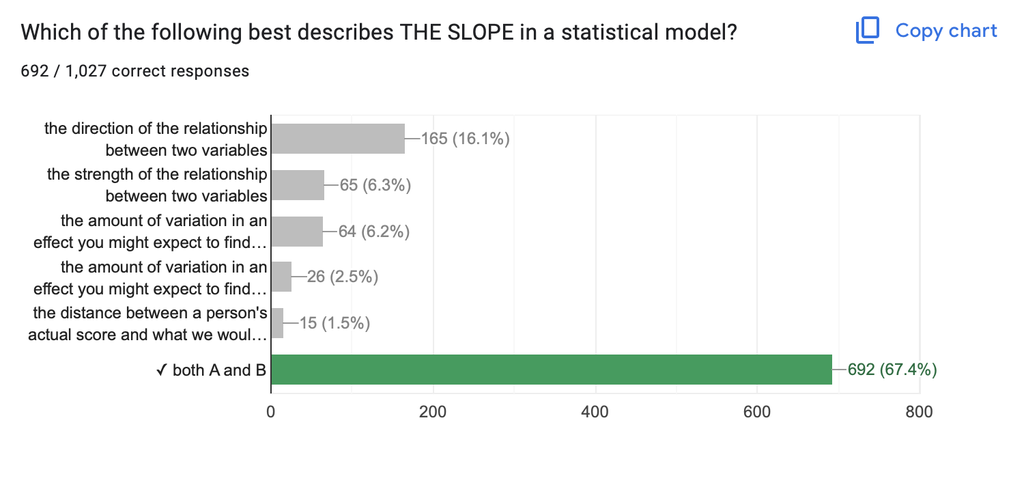

- The amount of variation in an effect you might expect to find due to chance if the null hypothesis were “true”.

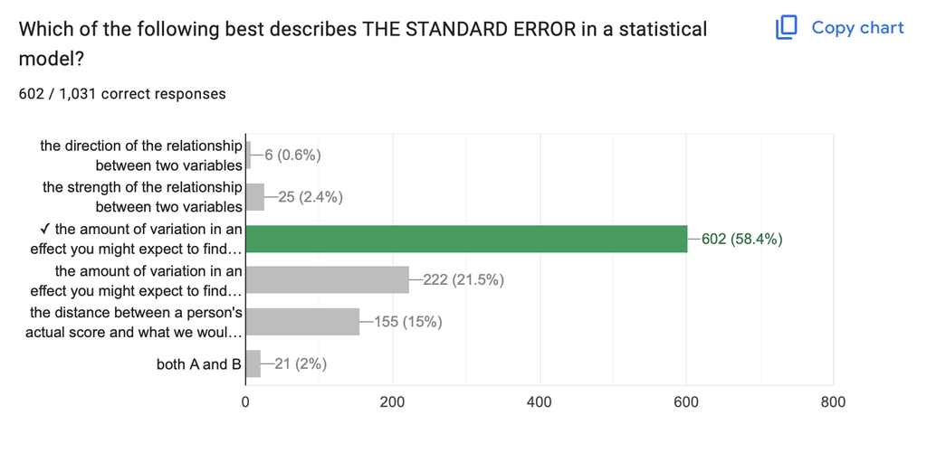

- …about slope! Large slope & sampling error = NOT SIGNIFICANT

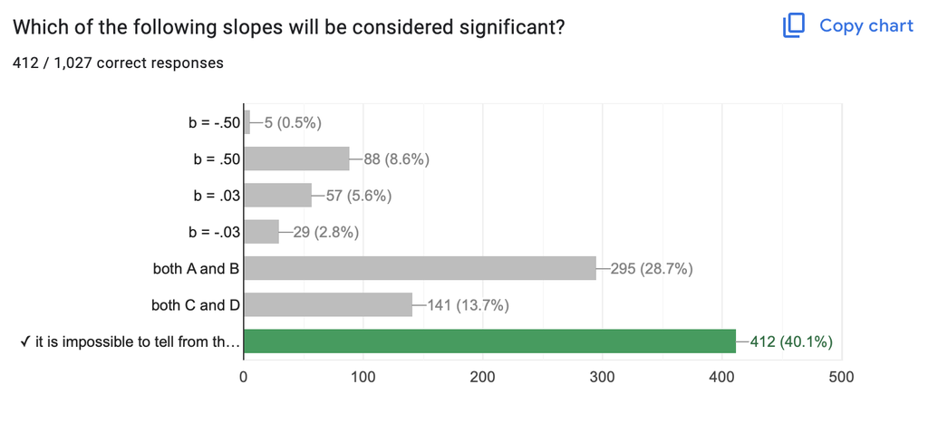

- **…about size :** you can be VERY confident that a small effect is not due to sampling error.
- **…about importance :** why does the effect matter?
- **…about truth :** our estimates of sampling error are all made up.

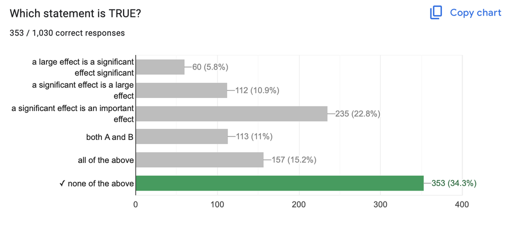

**A p-value of .03 means…there is a 3% chance that this slope (or a stronger slope) would be found due to chance if the true correlation was zero.**

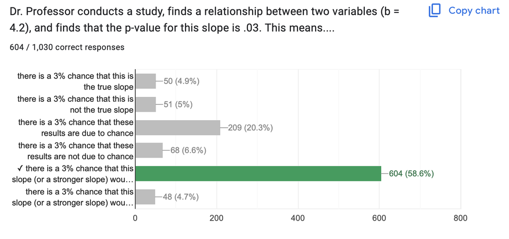

Haller, H., & Krauss, S. (2002). [Misinterpretations of significance: A problem students share with their teachers](https://www.metheval.uni-jena.de/lehre/0405-ws/evaluationuebung/haller.pdf). Methods of Psychological Research, 7(1), 1-20.

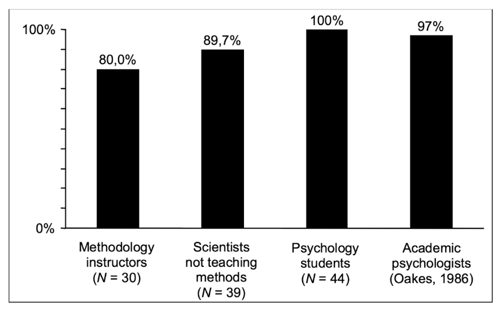

Break time.

[figure not shown]

## RECAP : $R^2$ In Real-Life

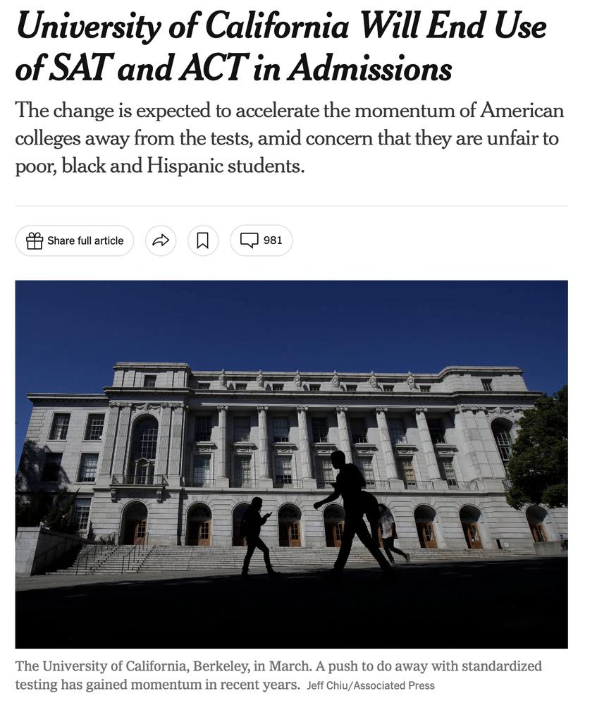

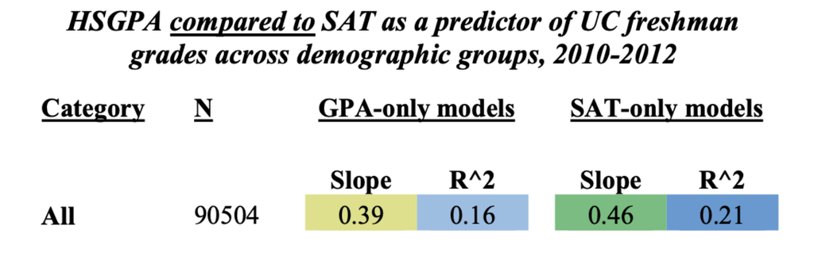

**DISCUSS :** what do these linear models tell us about the relationship between GPA, SAT (IVs) and freshman grades (DV)? Why did the researchers not report significance values?

### $R^2$ is r * r = a correlation

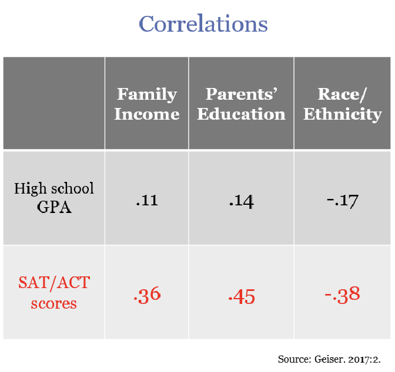

## Project Time : Milestone 3

- [**Final Project Description & Rubric**](https://docs.google.com/document/d/1DxiIxm_sRtm8t5FEOWhOJluJOo6ZPUI_eZTS13K4CxA/edit?usp=sharing)**.**
- [Final Project Vision Board](https://docs.google.com/spreadsheets/d/1WMn8SH-yQC-5bNcnQR-Jp5RWkxutVlKNmxCgMDgompI/edit?usp=sharing).

## The End.

[figure not shown]